# Integration of omics and clinical data of the hormonal, metabolic, inflammatory, and oxidative response in the different macronutrients of the diet

FINAL RESULTS

Edmond Geraud

16 de December, 2021

## Load the libraries

```r
> list.of.packages <- c("xlsx", "kableExtra", "dplyr", "ggplot2", "egg", "cowplot",
+     "patchwork", "gridExtra", "UsingR", "car", "lattice", "ggpubr", "ggbreak", "GGally",
+     "reshape2", "ggcorrplot", "corrplot", "rela", "ggrepel", "factoextra", "chemometrics",
+     "sparsepca", "vegan", "ca", "ade4", "pls", "OmicsPLS")
> new.packages <- list.of.packages[!(list.of.packages %in% installed.packages()[, "Package"])]  ## check for packages not installed
> if (length(new.packages)) install.packages(new.packages)  ## install packages if necessary
> res <- unlist(lapply(list.of.packages, require, character.only = T))  ## load packages needed for the session
> if (any(res == F)) {
+     list.of.packages[which(res == F)]  ## show those package if you have troubles to install.
+ }
>
> list.of.bioc.packages <- c("phyloseq", "pcaMethods", "ropls", "mixOmics")
> new.packages.bioc <- list.of.packages[!(list.of.bioc.packages %in% installed.packages()[,
+     "Package"])]
> if (length(new.packages.bioc)) BiocManager::install(new.packages.bioc)
> res.bioc <- unlist(lapply(list.of.bioc.packages, require, character.only = T))
> if (any(res.bioc == F)) {
+     list.of.packages[which(res.bioc == F)]  ## show those package if you have troubles to install.
+ }
```

# Functions for loading data (microbiome)

```r
> proces_bacteria <- function(datos,tipo){
+
+   Order <- bacteria_phylum.abs$Order
+   variables_in_bacteria <- general_data[general_data$Orden %in% Order , ]
+   Sample<-variables_in_bacteria$Paciente
+
+
+   if(tipo=="genera"){
+
+       Order <- Order
+
+       X <- datos[-1,-1]
+       X<-apply(X,2,as.numeric)
+       colnames(X) <- datos[1,2:ncol(datos)]
+       rownames(X) <- Sample
+       X.rel <- 100*X/rowSums(X)
+
+
+   } else if(tipo=="phylum"){
+
+       X <- datos[,-c(1:2)]
+       colnames(X) <- colnames(datos)[3:ncol(datos)]
+       rownames(X) <- Sample
+       X.rel<-100*X/rowSums(X)
+   }
+
+   GROUP <-variables_in_bacteria$GROUP
+   SEX <- variables_in_bacteria$SEX
+   OBESE<- variables_in_bacteria$OBESE
+
+   X<-as.data.frame(X)
+   X.rel<-as.data.frame(X.rel)
+
+   X$GROUP<-GROUP
+   X$SEX<-SEX
+   X$OBESE<-OBESE
+
+
+   X.rel$GROUP<-GROUP
+   X.rel$SEX<-SEX
+   X.rel$OBESE<-OBESE
+
+   return(list(abs=X,rel=X.rel))
+
+ }
>
>
> low.count.removal = function(
+                         data, # OTU count data frame of size n (sample) x p (OTU)
+                         percent=0.01 # cutoff chosen
+                         ){
+     keep.otu = which(colSums(data)*100/(sum(colSums(data))) > percent)
+     data.filter = data[,keep.otu]
+     return(list(data.filter = data.filter, keep.otu = keep.otu))
+ }
>
> relative.fn <-function(data){
+
+   return(100*data/rowSums(data))
+
+ }
```

# Load the data

## Clinical data.

```r
> general_data <- read.xlsx(file.path(params$folder.data, params$file_general), sheetIndex = 1)
> general_data$SEX <- factor(general_data$SEX, levels = c(0, 2), labels = c("Female",
+     "Male"))
> general_data$OBESE <- factor(general_data$OBESE, levels = c(0, 1), labels = c("No Obese",
+     "Obese"))
> general_data$GROUP <- factor(general_data$GROUP, levels = c(0, 1, 2), labels = c("Female",
+     "PCOS", "Male"))
```

## IP data.

```r
> IP_file <- file.path(params$folder.data, file = params$file_IP)  ## file path of the data
> IP.tmp <- read.xlsx(IP_file, sheetIndex = 1)
> IP <- IP.tmp[, -7]  # remove the missin values column
> IP$SEX <- factor(IP$SEX, levels = c(0, 2), labels = c("Female", "Male"))
> IP$OBESE <- factor(IP$OBESE, levels = c(0, 1), labels = c("No Obese", "Obese"))
> IP$GROUP <- factor(IP$GROUP, levels = c(0, 1, 2), labels = c("Female", "PCOS", "Male"))
```

## Metabolome data

```r
> metabolome_file <- file.path(params$folder.data, file = params$file_metabolome)  ## file path of the data
> metabolome.tmp <- read.xlsx(metabolome_file, sheetIndex = 1)  # read the data
> metabolites_name <- read.xlsx(metabolome_file, sheetIndex = 2)$Metabolitos  # read the names of the metabolites
> any(is.na(metabolome.tmp))  # there is a row of missing values.
```

```
[1] TRUE
```

```r
> metabolome <- metabolome.tmp[-nrow(metabolome.tmp), ]  ## remove the missing value row
> metabolome$GROUP <- general_data$GROUP  ## add GROUP variable
> metabolome$OBESE <- general_data$OBESE  ## add OBESE variables.
```

## Microbiome data.

```r
> bacteria_phylum.abs <- as.data.frame(read.xlsx(file.path(params$folder.data, params$file_microbiota),
+     sheetIndex = 1))
> bacteria_genera.abs <- as.data.frame(t(read.xlsx(file.path(params$folder.data, params$file_microbiota),
+     sheetIndex = 3)))
> phylum.list <- proces_bacteria(bacteria_phylum.abs, tipo = "phylum")
> genera.list <- proces_bacteria(bacteria_genera.abs, tipo = "genera")
>
> phylum.abs <- phylum.list$abs
> phylum.rel <- phylum.list$rel
> genera.abs <- genera.list$abs
> genera.rel <- genera.list$rel
```

# Preprocess data according to the microbiome.

Because we have less subjects on the microbiome, and we have phylum and genera with variables with no records across all samples, we have to clean that.

Furthermore, we have to take care only the basal levels across all blocks. Also we have to clean the data on the metabolome, IP for repeated variables.

```r
> variables_in_bacteria <- general_data[general_data$Orden %in% bacteria_phylum.abs$Order,
+     ]
```

Because, we only take care of the GROUP, and OBESE variables on the analysis, we can get rid off this variables and store them apart in a new object. Furthermore, we have to have the same names for the rows, so let’s keep it in another object.

```r
> sujetos <- variables_in_bacteria$Paciente
> GROUP <- variables_in_bacteria$GROUP
> OBESE <- variables_in_bacteria$OBESE
> interaccion <- with(variables_in_bacteria, interaction(GROUP, OBESE))
```

## Clinical data.

**NOTE we are going to include also on both levels of integration body measures** We exclude ISI because it is measured after the load of glucose, the mean values, to exclude redundancy of the data, ant the postprandial levels.

```r
> Clin.tmp <- variables_in_bacteria[, -c(1, 2, 3, 4, 5)]  # get rid off orden, paciente, sex, group and obese
> auc_clin <- colnames(Clin.tmp)[grep("AUC", colnames(Clin.tmp))]
> mean_basal_clin <- colnames(Clin.tmp)[grep("mean", colnames(Clin.tmp))]
> isi <- colnames(Clin.tmp)[grep("ISI", colnames(Clin.tmp))]
> variables_clin <- colnames(Clin.tmp)
> w <- c(which(variables_clin %in% auc_clin), which(variables_clin %in% mean_basal_clin),
+     which(variables_clin %in% isi))
> Clin <- Clin.tmp[, -w]
> rownames(Clin) <- sujetos
```

## IP data

```r
> IP.tmp <- IP[IP$Paciente %in% variables_in_bacteria$Paciente, ]
> redundant_variables <- c("Orden", "Paciente", "SEX", "GROUP", "OBESE", "BMI")
> variables_ip <- colnames(IP.tmp)
> auc_ip <- variables_ip[grep("AUC", variables_ip)]
> mean_ip <- variables_ip[grep("mean", variables_ip)]
> w <- c(which(variables_ip %in% redundant_variables), which(variables_ip %in% auc_ip),
+     which(variables_ip %in% mean_ip))
> IP.basal <- IP.tmp[, -w]
> rownames(IP.basal) <- sujetos
```

## Metabolome data.

```r
> metabolome.basal.tmp <- metabolome[metabolome$Order %in% variables_in_bacteria$Orden,
+     ]
> redundant_data_meta <- c("Order", "Sample", "GROUP", "OBESE")
> variables_meta <- colnames(metabolome.basal.tmp)
> mean_meta <- variables_meta[grep("mean", variables_meta)]
> auc_meta <- variables_meta[grep("AU[CG]", variables_meta)]
> w <- c(which(variables_meta %in% redundant_data_meta), which(variables_meta %in%
+     mean_meta), which(variables_meta %in% auc_meta))
> metabolome.basal <- metabolome.basal.tmp[, -w]
> rownames(metabolome.basal) <- sujetos
```

## Microbiome data.

### Phylum.

```r
> phylum.abs.tmp <- phylum.abs
> redundant_data_ph <- c("GROUP", "SEX", "OBESE")
> phylum.tmp <- phylum.abs.tmp[, -c(ncol(phylum.abs.tmp) - 2, ncol(phylum.abs.tmp) -
+     1, ncol(phylum.abs.tmp))]
> phylum <- phylum.tmp[, colSums(phylum.tmp) > 0]
> rownames(phylum) <- sujetos
> ## removal of unidentified phyla
> phylum <- phylum[, -grep("^ud", colnames(phylum))]
```

### Genus

```r
> genera.abs.tmp <- genera.abs
> redundant_data_ph <- c("GROUP", "SEX", "OBESE")
> genus.tmp.tmp <- genera.abs.tmp[, -c(ncol(genera.abs.tmp) - 2, ncol(genera.abs.tmp) -
+     1, ncol(genera.abs.tmp))]
> genus <- genus.tmp.tmp[, colSums(genus.tmp.tmp) > 0]
> rownames(genus) <- sujetos
> ## removal of genus unidentified
>
> genus <- genus[, -grep("^ud-", colnames(genus))]
```

## Pretreatment of microbiome data.

```r
> genus.offset <- genus + 1
> phylum.offset <- phylum + 1
> sum(which(genus.offset == 0))
```

```
[1] 0
```

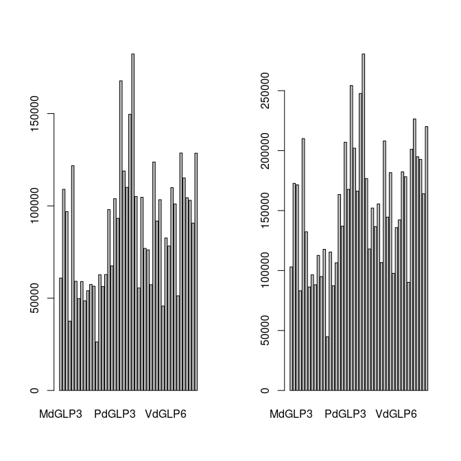

```r
> result.filter.genus <- low.count.removal(genus.offset, percent = 0.001)
> result.filter.phylum <- low.count.removal(phylum.offset, percent = 0)
>
> genus.filter <- result.filter.genus$data.filter
> phylum.filter <- result.filter.phylum$data.filter
>
> # length(result.filter$keep.otu)
> lib.size.genus <- apply(genus.filter, 1, sum)
> lib.size.phylum <- apply(phylum.filter, 1, sum)
> par(mfrow = c(1, 2))
> barplot(lib.size.genus)
> barplot(lib.size.phylum)
```

```r
> genus.clr <- logratio.transfo(as.matrix(genus.filter), logratio = "CLR", offset = 0)
> genus.rel <- relative.fn(genus)
>
>
> phylum.clr <- logratio.transfo(as.matrix(phylum.filter), logratio = "CLR", offset = 0)
> phylum.rel <- relative.fn(phylum)
```

# METABOLOME-MICROBIOME

## PLS2

### Phylum

```r
> datos <- list(metabolome = metabolome.basal, microbiome = phylum)
> pls_obj <- plsr(as.matrix(datos$metabolome) ~ as.matrix(datos$microbiome), val.type = "CV",
+     center = T, scale = T, explvar = T)
>
> rho <- diag(cor(pls_obj$scores[, 1:2], pls_obj$Yscores[, 1:2]))
>
> Group <- variables_in_bacteria$GROUP
> Group2 <- variables_in_bacteria$OBESE
> X <- pls_obj$scores
> colnames(X) <- paste0("met", paste0("comp", 1:length(colnames(X))))
> Y <- pls_obj$Yscores
> colnames(Y) <- paste0("micro", paste0("comp", 1:length(colnames(Y))))
> datos <- data.frame(cbind(X, Y))
> str(datos)
```

```
'data.frame':   46 obs. of  34 variables:
 $ metcomp1   : num  -0.314 -0.267 0.534 0.409 -0.511 ...
 $ metcomp2   : num  0.287 -0.1514 -0.0797 0.4271 -1.0674 ...
 $ metcomp3   : num  -0.249 0.156 0.494 0.182 2.865 ...
 $ metcomp4   : num  -0.278 1.352 -0.373 -0.353 -1.957 ...
 $ metcomp5   : num  -0.1752 -0.0307 0.135 -0.06 2.6267 ...
 $ metcomp6   : num  0.239 -1.543 0.591 0.167 1.062 ...
 $ metcomp7   : num  0.8491 -0.3553 -0.0965 0.4437 -0.2891 ...
 $ metcomp8   : num  0.759 0.344 0.747 -0.512 -1.221 ...
 $ metcomp9   : num  -0.528 0.753 -0.178 -0.664 0.912 ...
 $ metcomp10  : num  -0.39 0.496 0.602 -1.035 -0.976 ...
 $ metcomp11  : num  0.2134 -2.0497 -0.0224 -0.779 -0.7475 ...
 $ metcomp12  : num  -0.0588 0.544 -0.3384 -0.4489 0.2631 ...
 $ metcomp13  : num  0.0754 -0.9179 0.0678 0.4382 -0.566 ...
 $ metcomp14  : num  -0.927 -1.017 0.284 -0.929 -0.427 ...
```

[output cut: 20 more lines]

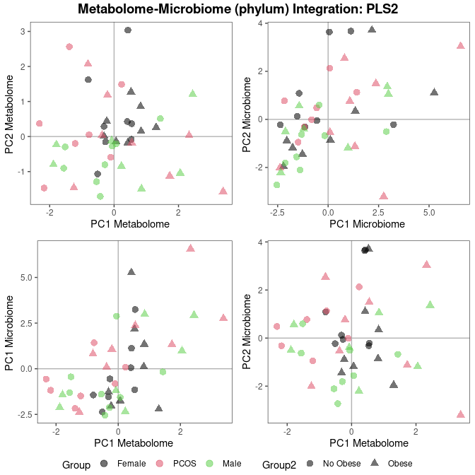

```r
> p1 <- ggplot(datos, aes(metcomp1, metcomp2)) + theme_article() + geom_hline(yintercept = 0,
+     color = "gray70") + geom_vline(xintercept = 0, color = "gray70") + geom_point(aes(color = Group,
+     shape = Group2), alpha = 0.55, size = 3) + coord_cartesian(xlim = c(min(datos[,
+     1]), max(datos[, 1]))) + scale_fill_discrete(name = "Group")
>
>
> grafico1 <- p1 + labs(x = c(paste("PC1 Metabolome ")), y = c(paste("PC2 Metabolome "))) +
+     theme(plot.title = element_text(hjust = 0.5), legend.position = "none") + scale_color_manual(values = 1:3)
>
> p2 <- ggplot(datos, aes(microcomp1, microcomp2)) + theme_article() + geom_hline(yintercept = 0,
+     color = "gray70") + geom_vline(xintercept = 0, color = "gray70") + geom_point(aes(color = Group,
+     shape = Group2), alpha = 0.55, size = 3) + coord_cartesian(xlim = c(min(datos[,
+     18]), max(datos[, 18]))) + scale_fill_discrete(name = "Group")
>
>
> grafico2 <- p2 + labs(x = c(paste("PC1 Microbiome ")), y = c(paste("PC2 Microbiome "))) +
+     theme(plot.title = element_text(hjust = 0.5), legend.position = "none") + scale_color_manual(values = 1:3)
>
> p3 <- ggplot(datos, aes(metcomp1, microcomp1)) + theme_article() + geom_hline(yintercept = 0,
+     color = "gray70") + geom_vline(xintercept = 0, color = "gray70") + geom_point(aes(color = Group,
+     shape = Group2), alpha = 0.55, size = 3) + coord_cartesian(xlim = c(min(datos[,
+     1]), max(datos[, 1]))) + scale_fill_discrete(name = "Group")
>
>
> grafico3 <- p3 + labs(x = c(paste("PC1 Metabolome ")), y = c(paste("PC1 Microbiome "))) +
+     theme(plot.title = element_text(hjust = 0.5), legend.position = "none") + scale_color_manual(values = 1:3)
>
>
> p4 <- ggplot(datos, aes(metcomp1, microcomp2)) + theme_article() + geom_hline(yintercept = 0,
+     color = "gray70") + geom_vline(xintercept = 0, color = "gray70") + geom_point(aes(color = Group,
+     shape = Group2), alpha = 0.55, size = 3) + coord_cartesian(xlim = c(min(datos[,
+     1]), max(datos[, 1]))) + scale_fill_discrete(name = "Group")
>
>
> grafico4 <- p4 + labs(x = c(paste("PC1 Metabolome")), y = c(paste("PC2 Microbiome"))) +
+     theme(plot.title = element_text(hjust = 0.5), legend.position = "none") + scale_color_manual(values = 1:3)
>
> pls2.plot <- ggarrange(grafico1, grafico2, grafico3, grafico4, common.legend = T,
+     nrow = 2, ncol = 2, legend = "bottom")
>
> annotate_figure(pls2.plot, top = text_grob("Metabolome-Microbiome (phylum) Integration: PLS2",
+     color = "black", face = "bold", size = 14))
```

## O2PLS

### phylum

#### Interaccion

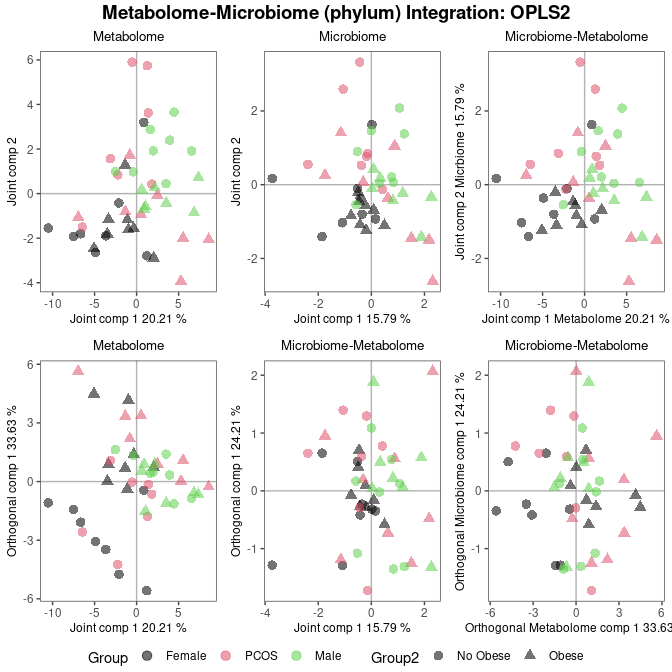

```r
> datos <- list(metabolome = metabolome.basal, microbiome = phylum)
> X <- scale(datos$metabolome)
> Y <- scale(datos$microbiome)
> n <- 1
> while (n < 2) {
+     res_cv <- crossval_o2m_adjR2(X, Y, 1:4, 0:4, 0:4, nr_folds = 3)
+     res_cv_min_mse <- res_cv[which.min(res_cv[, 1]), ]
+     n <- as.numeric(res_cv_min_mse[2])
+ }
>
>
> nx <- as.numeric(res_cv_min_mse[3])
> ny <- as.numeric(res_cv_min_mse[4])
>
> res <- o2m2(X = X, Y = Y, n = n, nx = nx, ny = ny)
>
>
>
> Group <- variables_in_bacteria$GROUP
> Group2 <- variables_in_bacteria$OBESE
> Tt <- data.frame(res$Tt)
> colnames(Tt) <- paste0("jointX_", paste0("comp", 1:length(colnames(Tt))))
> U <- data.frame(res$U)
> colnames(U) <- paste0("jointY_", paste0("comp", 1:length(colnames(U))))
> T_Y <- data.frame(res$T_Yosc)
> colnames(T_Y) <- paste0("OrthX_", paste0("comp", 1:length(colnames(T_Y))))
> U_X <- data.frame(res$U_Xosc)
> colnames(U_X) <- paste0("OrthY_", paste0("comp", 1:length(colnames(U_X))))
>
>
> ## Firstly let's compute the joint variantes.
>
> p1 <- ggplot(Tt, aes(jointX_comp1, jointX_comp2)) + theme_article() + geom_hline(yintercept = 0,
+     color = "gray70") + geom_vline(xintercept = 0, color = "gray70") + geom_point(aes(color = Group,
+     shape = Group2), alpha = 0.55, size = 3) + coord_cartesian(xlim = c(min(Tt[,
+     1]), max(Tt[, 1]))) + scale_fill_discrete(name = "Group")
>
>
> grafico1 <- p1 + labs(x = c(paste("Joint comp 1", round(100 * res$R2Xcorr, 2), "%")),
+     y = "Joint comp 2") + ggtitle(paste("Metabolome", sep = " ")) + theme(plot.title = element_text(hjust = 0.5,
+     size = 10), legend.position = "none", axis.title = element_text(size = 9)) +
+     scale_color_manual(values = 1:3)
>
> p2 <- ggplot(U, aes(jointY_comp1, jointY_comp2)) + theme_article() + geom_hline(yintercept = 0,
+     color = "gray70") + geom_vline(xintercept = 0, color = "gray70") + geom_point(aes(color = Group,
+     shape = Group2), alpha = 0.55, size = 3) + coord_cartesian(xlim = c(min(U[, 1]),
+     max(U[, 1]))) + scale_fill_discrete(name = "Group")
>
>
> grafico2 <- p2 + labs(x = c(paste("Joint comp 1", round(100 * res$R2Ycorr, 2), "%")),
+     y = "Joint comp 2") + ggtitle(paste("Microbiome", sep = " ")) + theme(plot.title = element_text(hjust = 0.5,
+     size = 10), legend.position = "none", axis.title = element_text(size = 9)) +
+     scale_color_manual(values = 1:3)
>
> ## Now let-s compute joint between
>
> datos <- data.frame(cbind(Tt, U))
> p3 <- ggplot(datos, aes(jointX_comp1, jointY_comp2)) + theme_article() + geom_hline(yintercept = 0,
+     color = "gray70") + geom_vline(xintercept = 0, color = "gray70") + geom_point(aes(color = Group,
+     shape = Group2), alpha = 0.55, size = 3) + coord_cartesian(xlim = c(min(datos[,
+     1]), max(datos[, 1]))) + scale_fill_discrete(name = "Group")
>
>
> grafico3 <- p3 + labs(x = c(paste("Joint comp 1 Metabolome", round(100 * res$R2Xcorr,
+     2), "%")), y = c(paste("Joint comp 2 Micrbiome", round(100 * res$R2Ycorr, 2),
+     "%"))) + ggtitle(paste("Microbiome-Metabolome", sep = " ")) + theme(plot.title = element_text(hjust = 0.5,
+     size = 10), legend.position = "none", axis.title = element_text(size = 9)) +
+     scale_color_manual(values = 1:3)
>
>
> ## let's compute thre joint and orthogonal between
>
>
> datos <- data.frame(cbind(Tt, T_Y))
> p4 <- ggplot(datos, aes(jointX_comp1, OrthX_comp1)) + theme_article() + geom_hline(yintercept = 0,
+     color = "gray70") + geom_vline(xintercept = 0, color = "gray70") + geom_point(aes(color = Group,
+     shape = Group2), alpha = 0.55, size = 3) + coord_cartesian(xlim = c(min(datos[,
+     1]), max(datos[, 1]))) + scale_fill_discrete(name = "Group")
>
>
> grafico4 <- p4 + labs(x = c(paste("Joint comp 1", round(100 * res$R2Xcorr, 2), "%")),
+     y = c(paste("Orthogonal comp 1", round(100 * res$R2X_YO, 2), "%"))) + ggtitle(paste("Metabolome",
+     sep = " ")) + theme(plot.title = element_text(hjust = 0.5, size = 10), legend.position = "none",
+     axis.title = element_text(size = 9)) + scale_color_manual(values = 1:3)
>
> datos <- data.frame(cbind(U, U_X))
> p5 <- ggplot(datos, aes(jointY_comp1, OrthY_comp1)) + theme_article() + geom_hline(yintercept = 0,
+     color = "gray70") + geom_vline(xintercept = 0, color = "gray70") + geom_point(aes(color = Group,
+     shape = Group2), alpha = 0.55, size = 3) + coord_cartesian(xlim = c(min(datos[,
+     1]), max(datos[, 1]))) + scale_fill_discrete(name = "Group")
>
>
> grafico5 <- p5 + labs(x = c(paste("Joint comp 1", round(100 * res$R2Ycorr, 2), "%")),
+     y = c(paste("Orthogonal comp 1", round(100 * res$R2Y_XO, 2), "%"))) + ggtitle(paste("Microbiome-Metabolome",
+     sep = " ")) + theme(plot.title = element_text(hjust = 0.5, size = 10), legend.position = "none",
+     axis.title = element_text(size = 9)) + scale_color_manual(values = 1:3)
>
> ## Now between orthogonal.
>
> datos <- data.frame(cbind(T_Y, U_X))
> p6 <- ggplot(datos, aes(OrthX_comp1, OrthY_comp1)) + theme_article() + geom_hline(yintercept = 0,
+     color = "gray70") + geom_vline(xintercept = 0, color = "gray70") + geom_point(aes(color = Group,
+     shape = Group2), alpha = 0.55, size = 3) + coord_cartesian(xlim = c(min(datos[,
+     1]), max(datos[, 1]))) + scale_fill_discrete(name = "Group")
>
>
> grafico6 <- p6 + labs(x = c(paste("Orthogonal Metabolome comp 1", round(100 * res$R2X_YO,
+     2), "%")), y = c(paste("Orthogonal Microbiome comp 1", round(100 * res$R2Y_XO,
+     2), "%"))) + ggtitle(paste("Microbiome-Metabolome", sep = " ")) + theme(plot.title = element_text(hjust = 0.5,
+     size = 10), legend.position = "none", axis.title = element_text(size = 9)) +
+     scale_color_manual(values = 1:3)
>
>
> o2pl2.plot <- ggarrange(grafico1, grafico2, grafico3, grafico4, grafico5, grafico6,
+     common.legend = T, legend = "bottom")
>
> annotate_figure(o2pl2.plot, top = text_grob("Metabolome-Microbiome (phylum) Integration: OPLS2",
+     color = "black", face = "bold", size = 14))
```

## DIABLO

### Phylum

#### interaccion

We are going to keep all variables since we do not have the power.

```r
> datos <- list(metabolome = metabolome.basal, microbiome = phylum.clr)
> res1.pls.met_micro <- mixOmics::pls(datos$metabolome, datos$microbiome, ncomp = 1)
> (rho <- cor(res1.pls.met_micro$variates$X, res1.pls.met_micro$variates$Y))
```

```
          comp1
comp1 0.4589274
```

```r
> design = matrix(rho, ncol = length(datos), nrow = length(datos), dimnames = list(names(datos),
+     names(datos)))
> diag(design) = 0
> design
```

```
           metabolome microbiome
metabolome  0.0000000  0.4589274
microbiome  0.4589274  0.0000000
```

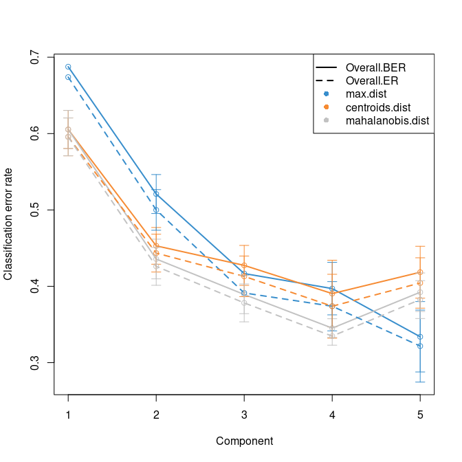

```r
> diablo.integro.interaccion <- block.splsda(datos, Y = interaccion, ncomp = 5, design = design)
>
> set.seed(55)  # For reproducibility, remove for your analyses
> perf.diablo.integro.interaccion = perf(diablo.integro.interaccion, validation = "Mfold",
+     folds = 10, nrepeat = 5)
>
> # perf.diablo.tcga$error.rate # Lists the different types of error rates
>
> # Plot of the error rates based on weighted vote
> plot(perf.diablo.integro.interaccion)
```

```r
> (ncomp.interaccion <- perf.diablo.integro.interaccion$choice.ncomp$WeightedVote["Overall.BER",
+     "centroids.dist"])
```

```
[1] 2
```

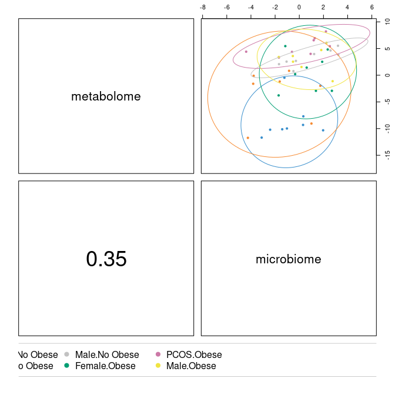

```r
> sgccda.res_met_gen.interaccion = block.splsda(X = datos, Y = interaccion, ncomp = ncomp.interaccion,
+     design = design)
>
> plotDiablo(sgccda.res_met_gen.interaccion, ncomp = 1)
```

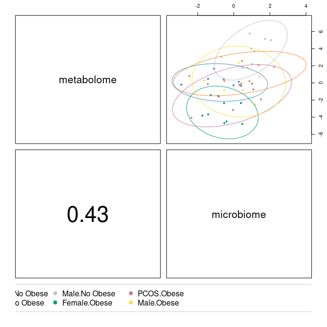

```r
> plotDiablo(sgccda.res_met_gen.interaccion, ncomp = 2)
```

```r
> # plotDiablo(sgccda.res_met_gen.interaccion, ncomp = 3)
>
> # plotIndiv(sgccda.res_met_gen.interaccion, ind.names = FALSE, legend = TRUE,
> # title = 'DIABLO')
```

SCORE PLOT

```r
> Group <- variables_in_bacteria$GROUP
> Group2 <- variables_in_bacteria$OBESE
> X <- sgccda.res_met_gen.interaccion$variates$metabolome
> colnames(X) <- paste0("met", colnames(X))
> Y <- sgccda.res_met_gen.interaccion$variates$microbiome
> colnames(Y) <- paste0("micro", colnames(Y))
> datos <- data.frame(cbind(X, Y))
> str(datos)
```

```
'data.frame':   46 obs. of  4 variables:
 $ metcomp1  : num  -9.32 -0.47 -7.7 -10.32 -10.21 ...
 $ metcomp2  : num  -0.276 0.136 0.461 -1.503 0.441 ...
 $ microcomp1: num  0.311 -1.232 0.334 1.969 -2.412 ...
 $ microcomp2: num  -0.0103 0.2807 -1.4222 -0.8775 -0.556 ...
```

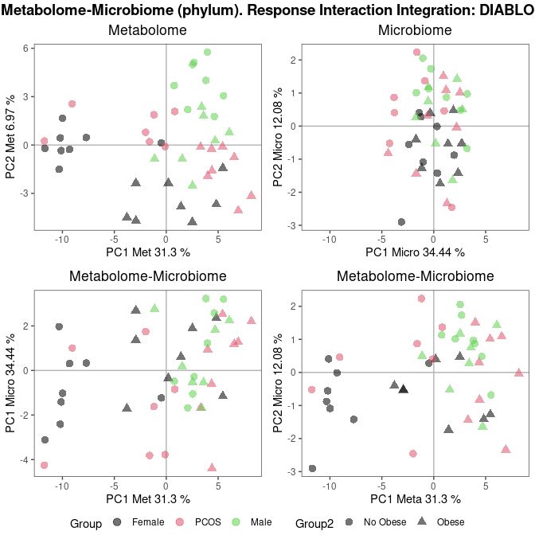

```r
> p1 <- ggplot(datos, aes(metcomp1, metcomp2)) + theme_article() + geom_hline(yintercept = 0,
+     color = "gray70") + geom_vline(xintercept = 0, color = "gray70") + geom_point(aes(color = Group,
+     shape = Group2), alpha = 0.55, size = 3) + coord_cartesian(xlim = c(min(datos[,
+     1]), max(datos[, 1]))) + scale_fill_discrete(name = "Group")
>
>
> grafico1 <- p1 + labs(x = c(paste("PC1 Met", round(100 * sgccda.res_met_gen.interaccion$prop_expl_var$metabolome[1],
+     2), "%")), y = c(paste("PC2 Met", round(100 * sgccda.res_met_gen.interaccion$prop_expl_var$metabolome[2],
+     2), "%"))) + ggtitle(paste("Metabolome", sep = " ")) + theme(plot.title = element_text(hjust = 0.5),
+     legend.position = "none") + scale_color_manual(values = 1:3)
>
> p2 <- ggplot(datos, aes(microcomp1, microcomp2)) + theme_article() + geom_hline(yintercept = 0,
+     color = "gray70") + geom_vline(xintercept = 0, color = "gray70") + geom_point(aes(color = Group,
+     shape = Group2), alpha = 0.55, size = 3) + coord_cartesian(xlim = c(min(datos[,
+     1]), max(datos[, 1]))) + scale_fill_discrete(name = "Group")
>
>
> grafico2 <- p2 + labs(x = c(paste("PC1 Micro", round(100 * sgccda.res_met_gen.interaccion$prop_expl_var$microbiome[1],
+     2), "%")), y = c(paste("PC2 Micro", round(100 * sgccda.res_met_gen.interaccion$prop_expl_var$microbiome[2],
+     2), "%"))) + ggtitle(paste("Microbiome", sep = " ")) + theme(plot.title = element_text(hjust = 0.5),
+     legend.position = "none") + scale_color_manual(values = 1:3)
>
> p3 <- ggplot(datos, aes(metcomp1, microcomp1)) + theme_article() + geom_hline(yintercept = 0,
+     color = "gray70") + geom_vline(xintercept = 0, color = "gray70") + geom_point(aes(color = Group,
+     shape = Group2), alpha = 0.55, size = 3) + coord_cartesian(xlim = c(min(datos[,
+     1]), max(datos[, 1]))) + scale_fill_discrete(name = "Group")
>
>
> grafico3 <- p3 + labs(x = c(paste("PC1 Met", round(100 * sgccda.res_met_gen.interaccion$prop_expl_var$metabolome[1],
+     2), "%")), y = c(paste("PC1 Micro", round(100 * sgccda.res_met_gen.interaccion$prop_expl_var$microbiome[1],
+     2), "%"))) + ggtitle(paste("Metabolome-Microbiome", sep = " ")) + theme(plot.title = element_text(hjust = 0.5),
+     legend.position = "none") + scale_color_manual(values = 1:3)
>
>
> p4 <- ggplot(datos, aes(metcomp1, microcomp2)) + theme_article() + geom_hline(yintercept = 0,
+     color = "gray70") + geom_vline(xintercept = 0, color = "gray70") + geom_point(aes(color = Group,
+     shape = Group2), alpha = 0.55, size = 3) + coord_cartesian(xlim = c(min(datos[,
+     1]), max(datos[, 1]))) + scale_fill_discrete(name = "Group")
>
>
> grafico4 <- p4 + labs(x = c(paste("PC1 Meta", round(100 * sgccda.res_met_gen.interaccion$prop_expl_var$metabolome[1],
+     2), "%")), y = c(paste("PC2 Micro", round(100 * sgccda.res_met_gen.interaccion$prop_expl_var$microbiome[2],
+     2), "%"))) + ggtitle(paste("Metabolome-Microbiome", sep = " ")) + theme(plot.title = element_text(hjust = 0.5),
+     legend.position = "none") + scale_color_manual(values = 1:3)
>
> p <- ggarrange(grafico1, grafico2, grafico3, grafico4, common.legend = T, nrow = 2,
+     ncol = 2, legend = "bottom")
> annotate_figure(p, top = text_grob("Metabolome-Microbiome (phylum). Response Interaction Integration: DIABLO",
+     color = "black", face = "bold", size = 14))
```

LOADIGNS PLOT.

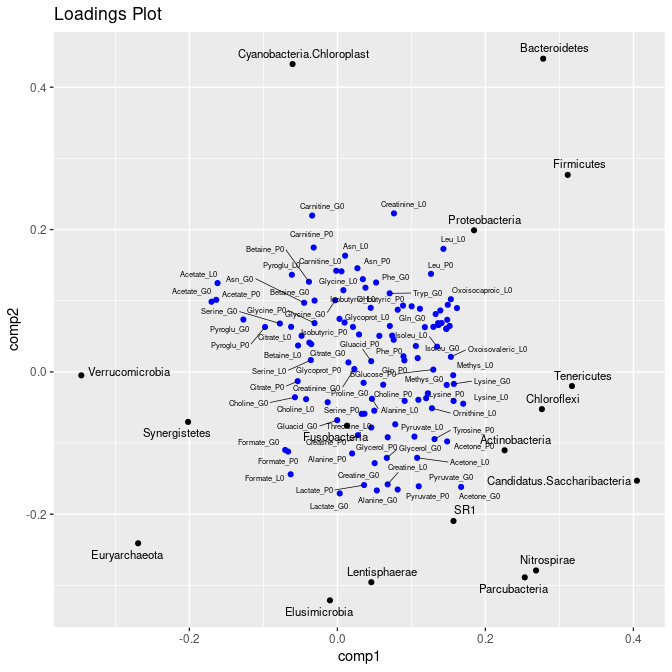

```r
> X <- data.frame(sgccda.res_met_gen.interaccion$loadings$metabolome)
> Y <- data.frame(sgccda.res_met_gen.interaccion$loadings$microbiome)
> # colnames(X) <-paste0('met',colnames(X)) colnames(Y) <-
> # paste0('micro',colnames(Y))
> plot1 <- ggplot() + geom_point(data = X, aes(comp1, comp2), label = rownames(X),
+     color = "blue") + geom_text_repel(data = X, aes(comp1, comp2, label = rownames(X)),
+     segment.size = 0.25, size = 2) + geom_point(data = Y, aes(comp1, comp2), color = "black") +
+     geom_text_repel(data = Y, aes(comp1, comp2, label = rownames(Y)), segment.size = 0.25,
+         size = 3) + ggtitle("Loadings Plot")
> plot1
```

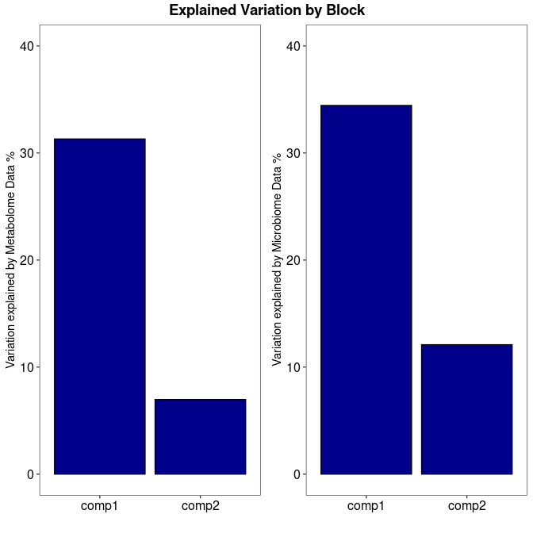

```r
> met_prop <- sgccda.res_met_gen.interaccion$prop_expl_var$metabolome
> mic_prop <- sgccda.res_met_gen.interaccion$prop_expl_var$microbiome
> var.exp <- 100 * data.frame(met = met_prop, mic = mic_prop)
> var.exp$comps <- rownames(var.exp)
>
>
> p3 <- ggplot(data = var.exp, aes(x = comps, y = met)) + geom_bar(stat = "identity",
+     col = "black", fill = "darkblue") + theme_article() + labs(y = "Variation explained by Metabolome Data %",
+     x = "") + theme(axis.text = element_text(size = 12, color = "black")) + coord_cartesian(ylim = c(-0,
+     40))
>
> p4 <- ggplot(data = var.exp, aes(x = comps, y = mic)) + geom_bar(stat = "identity",
+     col = "black", fill = "darkblue") + theme_article() + labs(y = "Variation explained by Microbiome Data %",
+     x = "") + theme(axis.text = element_text(size = 12, color = "black")) + coord_cartesian(ylim = c(-0,
+     40))
>
>
>
> var.expl.plot <- ggarrange(p3, p4)
> annotate_figure(var.expl.plot, top = text_grob("Explained Variation by Block", color = "black",
+     face = "bold", size = 14))
```

```r
> fn.contrib <- function(p, grupcon1, grupcon2) {
+
+     p.obj <- p[p[, "GroupContrib"] == grupcon1 & p[, paste0("Contrib.", grupcon2)] ==
+         T, ]
+     p.obj$variable <- rownames(p.obj)
+     p.obj$variable <- factor(p.obj$variable, levels = p.obj$variable[order(p.obj$importance)])
+     grafico <- ggplot(data = p.obj, aes(x = variable, y = importance)) + geom_bar(stat = "identity",
+         col = "black", fill = "blue") + coord_flip() + theme_article() + ggtitle(paste(c(unlist(strsplit(grupcon2,
+         "[.]"))), collapse = " ")) + theme(axis.text = element_text(size = 6, color = "black"))
+     return(grafico)
+ }
>
> p <- plotLoadings(sgccda.res_met_gen.interaccion, contrib = "max", block = 1, plot = F,
+     ndisplay = 70)
> q <- plotLoadings(sgccda.res_met_gen.interaccion, contrib = "max", block = 2, plot = F)
>
> (grupcon1. <- sort(unique(p$GroupContrib)))
```

```
[1] "Female.No Obese" "Female.Obese"    "Male.No Obese"   "Male.Obese"
[5] "PCOS.No Obese"   "PCOS.Obese"
```

```r
> (grupcon2. <- sort(colnames(p)[grep("^[cig]", invert = T, ignore.case = T, colnames(p))]))
```

```
[1] "Female.No.Obese" "Female.Obese"    "Male.No.Obese"   "Male.Obese"
[5] "PCOS.No.Obese"   "PCOS.Obese"
```

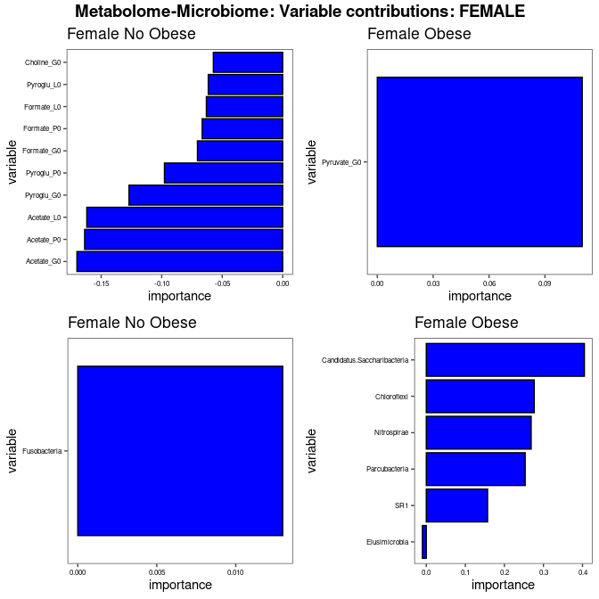

```r
> grupos.con <- cbind(grupcon1., grupcon2.)
>
> aux1 <- list()
> aux2 <- list()
> for (i in 1:2) {
+
+     aux1[[i]] <- fn.contrib(p, grupcon1 = grupos.con[i, 1], grupcon2 = grupos.con[i,
+         2])
+     aux2[[i]] <- fn.contrib(q, grupcon1 = grupos.con[i, 1], grupcon2 = grupos.con[i,
+         2])
+ }
>
> plot_female <- ggarrange(aux1[[1]], aux1[[2]], aux2[[1]], aux2[[2]])
> annotate_figure(plot_female, top = text_grob("Metabolome-Microbiome: Variable contributions: FEMALE",
+     color = "black", face = "bold", size = 14))
```

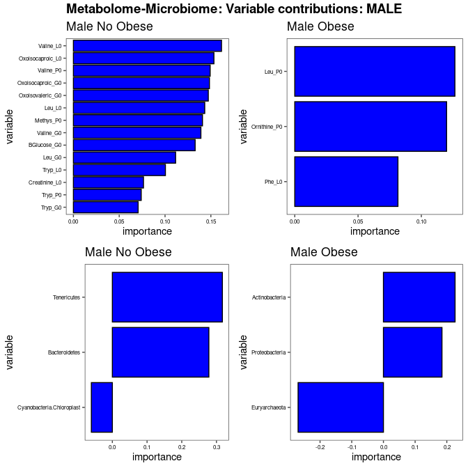

```r
> for (i in 3:4) {
+
+     aux1[[i]] <- fn.contrib(p, grupcon1 = grupos.con[i, 1], grupcon2 = grupos.con[i,
+         2])
+     aux2[[i]] <- fn.contrib(q, grupcon1 = grupos.con[i, 1], grupcon2 = grupos.con[i,
+         2])
+ }
>
> plot_male <- ggarrange(aux1[[3]], aux1[[4]], aux2[[3]], aux2[[4]])
> annotate_figure(plot_male, top = text_grob("Metabolome-Microbiome: Variable contributions: MALE",
+     color = "black", face = "bold", size = 14))
```

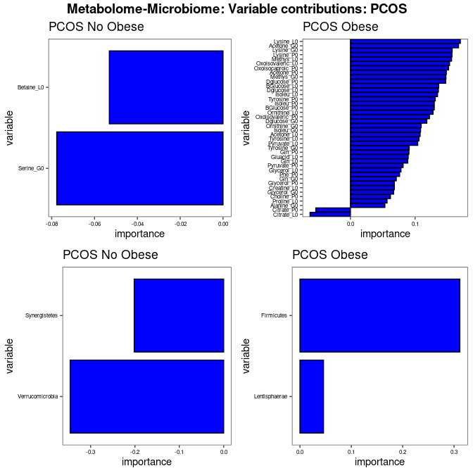

```r
> for (i in 5:6) {
+
+     aux1[[i]] <- fn.contrib(p, grupcon1 = grupos.con[i, 1], grupcon2 = grupos.con[i,
+         2])
+     aux2[[i]] <- fn.contrib(q, grupcon1 = grupos.con[i, 1], grupcon2 = grupos.con[i,
+         2])
+ }
>
> plot_pcos <- ggarrange(aux1[[5]], aux1[[6]], aux2[[5]], aux2[[6]])
> annotate_figure(plot_pcos, top = text_grob("Metabolome-Microbiome: Variable contributions: PCOS",
+     color = "black", face = "bold", size = 14))
```

# TOTAL INTEGRATION

## Blocks with Phykum data transformed

Firstly let’s investigate the relationship between blocks.

```r
> datos <- list(clinical_data = Clin, IP = IP.basal, metabolome = metabolome.basal,
+     microbiome = phylum.clr)
>
> res1.pls.met_micro <- mixOmics::pls(datos$metabolome, datos$microbiome, ncomp = 1)
> (rho_met_micro <- cor(res1.pls.met_micro$variates$X, res1.pls.met_micro$variates$Y))
```

```
          comp1
comp1 0.4589274
```

```r
> res1.pls.met_IP <- mixOmics::pls(datos$IP, datos$metabolome, ncomp = 1)
> (rho_met_ip <- cor(res1.pls.met_IP$variates$X, res1.pls.met_IP$variates$Y))
```

```
          comp1
comp1 0.6419853
```

```r
> res1.pls.met_clin <- mixOmics::pls(datos$metabolome, datos$clinical_data, ncomp = 1)
> (rho_pls_met_clin <- cor(res1.pls.met_clin$variates$X, res1.pls.met_clin$variates$Y))
```

```
          comp1
comp1 0.7204314
```

```r
> res1.pls_micro_clin <- mixOmics::pls(datos$microbiome, datos$clinical_data, ncomp = 1)
> (rho_pls_micro_clin <- cor(res1.pls_micro_clin$variates$X, res1.pls_micro_clin$variates$Y))
```

```
          comp1
comp1 0.4958948
```

```r
> res1.pls_micro_IP <- mixOmics::pls(datos$microbiome, datos$IP, ncomp = 1)
> (rho_pls_micro_IP <- cor(res1.pls_micro_IP$variates$X, res1.pls_micro_IP$variates$Y))
```

```
          comp1
comp1 0.4204233
```

```r
> res1.pls_IP_clin <- mixOmics::pls(datos$IP, datos$clinical_data, ncomp = 1)
> (rho_pls_IP_clin <- cor(res1.pls_IP_clin$variates$X, res1.pls_IP_clin$variates$Y))
```

```
          comp1
comp1 0.7848197
```

```r
> design = matrix(c(0, rho_pls_IP_clin, rho_pls_met_clin, rho_pls_micro_clin, rho_pls_IP_clin,
+     0, rho_met_ip, rho_pls_micro_IP, rho_pls_met_clin, rho_met_ip, 0, rho_met_micro,
+     rho_pls_micro_clin, rho_pls_micro_IP, rho_met_micro, 0), ncol = 4, dimnames = list(names(datos),
+     names(datos)))
> design
```

```
              clinical_data        IP metabolome microbiome
clinical_data     0.0000000 0.7848197  0.7204314  0.4958948
IP                0.7848197 0.0000000  0.6419853  0.4204233
metabolome        0.7204314 0.6419853  0.0000000  0.4589274
microbiome        0.4958948 0.4204233  0.4589274  0.0000000
```

Now let’s observe the optimal number of components.

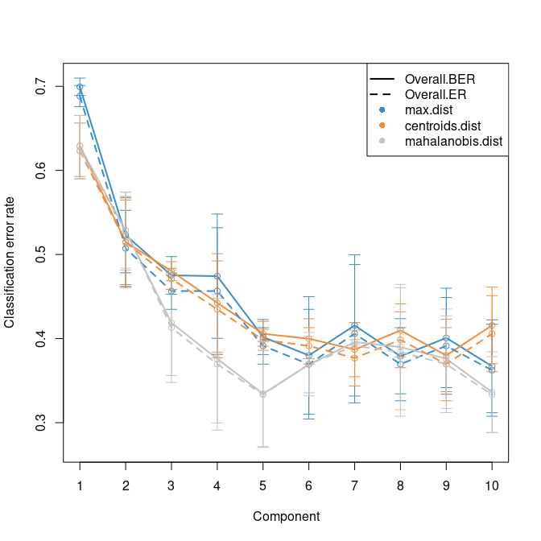

```r
> sgccda.res_total_1 = block.splsda(X = datos, Y = interaccion, ncomp = 10, design = design)
>
> set.seed(123)  # for reproducibility, only when the `cpus' argument is not used
> # this code takes a couple of min to run
> perf.diablo_toltal_1 = mixOmics::perf(sgccda.res_total_1, validation = "Mfold", folds = 5,
+     nrepeat = 3)
>
> # perf.diablo # lists the different outputs
> plot(perf.diablo_toltal_1)
```

```r
> perf.diablo_toltal_1$choice.ncomp$WeightedVote
```

```
            max.dist centroids.dist mahalanobis.dist
Overall.ER         8              5                3
Overall.BER        8              5                3
```

```r
> (ncomp = perf.diablo_toltal_1$choice.ncomp$WeightedVote["Overall.BER", "centroids.dist"])
```

```
[1] 5
```

```r
> sgccda.res_genus = block.splsda(X = datos, Y = interaccion, ncomp = ncomp, design = design)
```

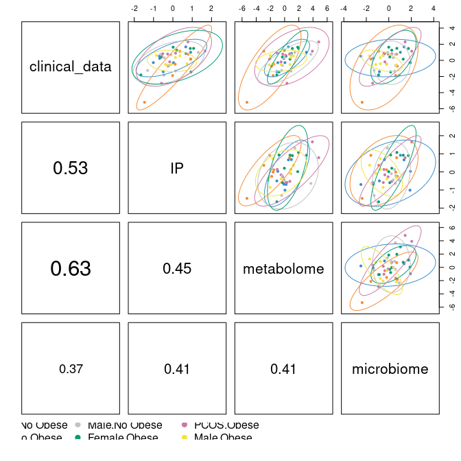

```r
> plotDiablo(sgccda.res_genus, ncomp = 5)
```

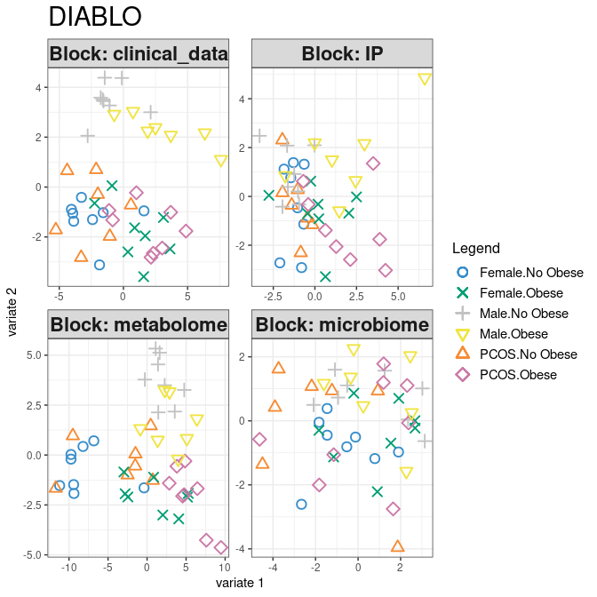

```r
> plotIndiv(sgccda.res_genus, ind.names = FALSE, legend = TRUE, title = "DIABLO", study = "global")
```

SCORE PLOT

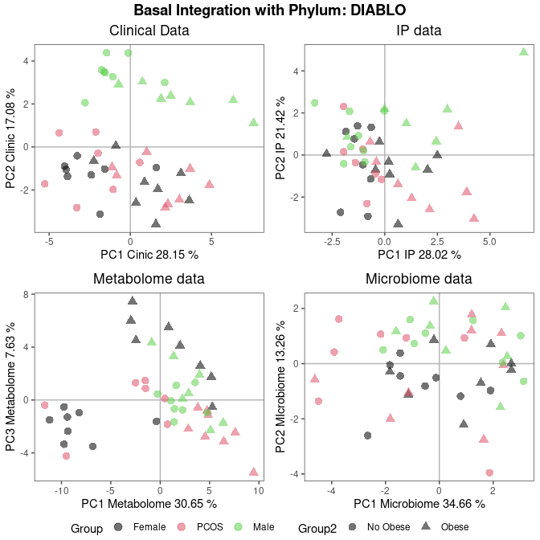

```r
> Group <- variables_in_bacteria$GROUP
> Group2 <- variables_in_bacteria$OBESE
> X <- data.frame(sgccda.res_genus$variates$clinical_data)
> colnames(X) <- paste0("C_", colnames(X))
> Y <- data.frame(sgccda.res_genus$variates$IP)
> colnames(Y) <- paste0("IP_", colnames(Y))
> Z <- data.frame(sgccda.res_genus$variates$metabolome)
> colnames(Z) <- paste0("Met_", colnames(Z))
> W <- data.frame(sgccda.res_genus$variates$microbiome)
> colnames(W) <- paste0("Micro_", colnames(W))
>
> p1 <- ggplot(X, aes(C_comp1, C_comp2)) + theme_article() + geom_hline(yintercept = 0,
+     color = "gray70") + geom_vline(xintercept = 0, color = "gray70") + geom_point(aes(color = Group,
+     shape = Group2), alpha = 0.55, size = 3) + coord_cartesian(xlim = c(min(X[, 1]),
+     max(X[, 1]))) + scale_fill_discrete(name = "Group")
>
>
> grafico1 <- p1 + labs(x = c(paste("PC1 Cinic", round(100 * sgccda.res_genus$prop_expl_var$clinical_data[1],
+     2), "%")), y = c(paste("PC2 Clinic", round(100 * sgccda.res_genus$prop_expl_var$clinical_data[2],
+     2), "%"))) + ggtitle(paste("Clinical Data", sep = " ")) + theme(plot.title = element_text(hjust = 0.5),
+     legend.position = "none") + scale_color_manual(values = 1:3)
>
> p2 <- ggplot(Y, aes(IP_comp1, IP_comp2)) + theme_article() + geom_hline(yintercept = 0,
+     color = "gray70") + geom_vline(xintercept = 0, color = "gray70") + geom_point(aes(color = Group,
+     shape = Group2), alpha = 0.55, size = 3) + coord_cartesian(xlim = c(min(Y[, 1]),
+     max(Y[, 1]))) + scale_fill_discrete(name = "Group")
>
>
> grafico2 <- p2 + labs(x = c(paste("PC1 IP", round(100 * sgccda.res_genus$prop_expl_var$IP[1],
+     2), "%")), y = c(paste("PC2 IP", round(100 * sgccda.res_genus$prop_expl_var$IP[2],
+     2), "%"))) + ggtitle(paste("IP data", sep = " ")) + theme(plot.title = element_text(hjust = 0.5),
+     legend.position = "none") + scale_color_manual(values = 1:3)
>
> p3 <- ggplot(Z, aes(Met_comp1, Met_comp3)) + theme_article() + geom_hline(yintercept = 0,
+     color = "gray70") + geom_vline(xintercept = 0, color = "gray70") + geom_point(aes(color = Group,
+     shape = Group2), alpha = 0.55, size = 3) + coord_cartesian(xlim = c(min(Z[, 1]),
+     max(Z[, 1]))) + scale_fill_discrete(name = "Group")
>
>
> grafico3 <- p3 + labs(x = c(paste("PC1 Metabolome", round(100 * sgccda.res_genus$prop_expl_var$metabolome[1],
+     2), "%")), y = c(paste("PC3 Metabolome", round(100 * sgccda.res_genus$prop_expl_var$metabolome[3],
+     2), "%"))) + ggtitle(paste("Metabolome data", sep = " ")) + theme(plot.title = element_text(hjust = 0.5),
+     legend.position = "none") + scale_color_manual(values = 1:3)
>
>
> p4 <- ggplot(W, aes(Micro_comp1, Micro_comp2)) + theme_article() + geom_hline(yintercept = 0,
+     color = "gray70") + geom_vline(xintercept = 0, color = "gray70") + geom_point(aes(color = Group,
+     shape = Group2), alpha = 0.55, size = 3) + coord_cartesian(xlim = c(min(W[, 1]),
+     max(W[, 1]))) + scale_fill_discrete(name = "Group")
>
>
> grafico4 <- p4 + labs(x = c(paste("PC1 Microbiome", round(100 * sgccda.res_genus$prop_expl_var$microbiome[1],
+     2), "%")), y = c(paste("PC2 MIcrobiome", round(100 * sgccda.res_genus$prop_expl_var$microbiome[2],
+     2), "%"))) + ggtitle(paste("Microbiome data", sep = " ")) + theme(plot.title = element_text(hjust = 0.5),
+     legend.position = "none") + scale_color_manual(values = 1:3)
>
> p <- ggarrange(grafico1, grafico2, grafico3, grafico4, common.legend = T, nrow = 2,
+     ncol = 2, legend = "bottom")
> annotate_figure(p, top = text_grob("Basal Integration with Phylum: DIABLO", color = "black",
+     face = "bold", size = 14))
```

```r
> (p <- plotLoadings(sgccda.res_genus, plot = F, contrib = "min", comp = 1))
```

```
                            Female.No.Obese PCOS.No.Obese Male.No.Obese
Candidatus.Saccharibacteria     -0.36364017   -0.66731158   0.102338250
Verrucomicrobia                  0.31933767    0.53910258  -0.189200980
Tenericutes                     -0.22107597   -0.72248108   0.439321080
Nitrospirae                     -0.13833436   -0.69835915   0.116184100
Actinobacteria                   0.07999619   -0.56147563  -0.007370860
Parcubacteria                   -0.17876460   -0.69516767   0.055928786
Proteobacteria                  -0.10485245   -0.25163973   0.159865678
Firmicutes                      -0.34769910   -0.06752623   0.158762966
Chloroflexi                     -0.16399732   -0.72776973   0.477622970
Synergistetes                    0.36033496    0.39054703  -0.146085714
Euryarchaeota                    0.04320968    0.35903132  -0.615307967
SR1                             -0.14689906   -0.25735896   0.082609090
Cyanobacteria.Chloroplast       -0.08104699    0.30975148   0.452657431
Fusobacteria                     0.28606336   -0.39939432   0.001142257
Bacteroidetes                   -0.58177479    0.14572797   0.597675652
Elusimicrobia                    0.29887655   -0.73090794   0.073228950
Lentisphaerae                    0.13251153   -0.32417111  -0.113446993
                            Female.Obese   PCOS.Obese  Male.Obese
Candidatus.Saccharibacteria  0.464962173  0.036770659  0.39253340
Verrucomicrobia             -0.137986320  0.125584177 -0.67365635
Tenericutes                  0.363189178 -0.026393213  0.08814843
Nitrospirae                  0.514237720  0.079108927  0.04556327
Actinobacteria              -0.013096095  0.083582111  0.39791980
Parcubacteria                0.422977021  0.021741490  0.32730172
Proteobacteria              -0.170726490  0.000395176  0.38343183
Firmicutes                  -0.366848737  0.347198462  0.30591070
Chloroflexi                  0.492941692  0.054901069 -0.25676560
Synergistetes               -0.371060707  0.133636207 -0.36406103
Euryarchaeota                0.006357331 -0.210867196  0.52852085
SR1                          0.441547890  0.049177117 -0.22999537
Cyanobacteria.Chloroplast   -0.200908318 -0.228640834 -0.24353581
Fusobacteria                 0.160344541 -0.154508734  0.06448984
Bacteroidetes               -0.111510958 -0.069365782  0.04281589
Elusimicrobia                0.466197158  0.036627438 -0.26901216
Lentisphaerae                0.206161186  0.401247160 -0.39179791
                            Contrib.Female.No.Obese Contrib.PCOS.No.Obese
Candidatus.Saccharibacteria                   FALSE                  TRUE
Verrucomicrobia                               FALSE                 FALSE
Tenericutes                                   FALSE                  TRUE
```

[output cut: 53 more lines]

```
Tenericutes                   PCOS.No Obese #F68B33  0.35254888
Nitrospirae                   PCOS.No Obese #F68B33  0.29299725
Actinobacteria                PCOS.No Obese #F68B33  0.28854738
Parcubacteria                 PCOS.No Obese #F68B33  0.28671820
Proteobacteria                PCOS.No Obese #F68B33  0.26362069
Firmicutes                     Female.Obese #009E73  0.22981922
Chloroflexi                   PCOS.No Obese #F68B33  0.20708182
Synergistetes                  Female.Obese #009E73 -0.20307504
Euryarchaeota                 Male.No Obese #C2C2C2 -0.17259628
SR1                           PCOS.No Obese #F68B33  0.14366712
Cyanobacteria.Chloroplast        Male.Obese #F0E442 -0.08955595
Fusobacteria                  PCOS.No Obese #F68B33  0.06244868
Bacteroidetes               Female.No Obese #388ECC  0.06020189
Elusimicrobia                 PCOS.No Obese #F68B33  0.04033275
Lentisphaerae                    Male.Obese #F0E442  0.02963118
```

```r
> p <- plotLoadings(sgccda.res_genus, contrib = "max", block = 1, plot = F, method = "mean",
+     comp = 1)
> q <- plotLoadings(sgccda.res_genus, contrib = "max", block = 2, plot = F, method = "mean",
+     comp = 1)
> r <- plotLoadings(sgccda.res_genus, contrib = "max", block = 3, plot = F, method = "mean",
+     comp = 1)
> s <- plotLoadings(sgccda.res_genus, contrib = "max", block = 4, plot = F, method = "mean",
+     comp = 1)
>
> (grupcon1. <- sort(unique(p$GroupContrib)))
```

```
[1] "Female.No Obese" "Female.Obese"    "Male.No Obese"   "Male.Obese"
[5] "PCOS.No Obese"   "PCOS.Obese"
```

```r
> (grupcon2. <- sort(colnames(p)[grep("^[cig]", invert = T, ignore.case = T, colnames(p))]))
```

```
[1] "Female.No.Obese" "Female.Obese"    "Male.No.Obese"   "Male.Obese"
[5] "PCOS.No.Obese"   "PCOS.Obese"
```

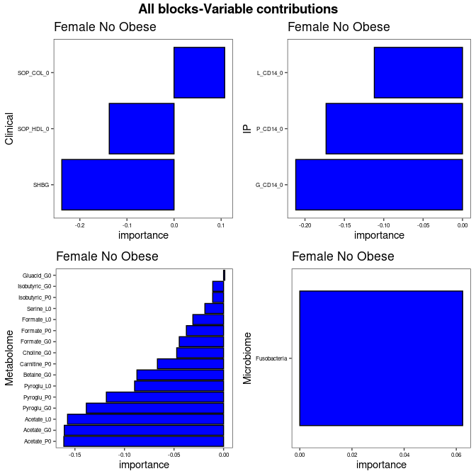

```r
> grupos.con <- cbind(grupcon1., grupcon2.)
>
> lista_loads <- list(p, q, r, s)
> aux1 <- vector(mode = "list", length = 4)
> block.name <- c("Clinical", "IP", "Metabolome", "Microbiome")
> for (i in 1:length(lista_loads)) {
+
+     aux1[[i]] <- fn.contrib(lista_loads[[i]], grupcon1 = grupos.con[1, 1], grupcon2 = grupos.con[1,
+         2]) + labs(x = block.name[i])
+ }
>
> plot_female <- ggarrange(aux1[[1]], aux1[[2]], aux1[[3]], aux1[[4]])
> annotate_figure(plot_female, top = text_grob("All blocks-Variable contributions",
+     color = "black", face = "bold", size = 14))
```

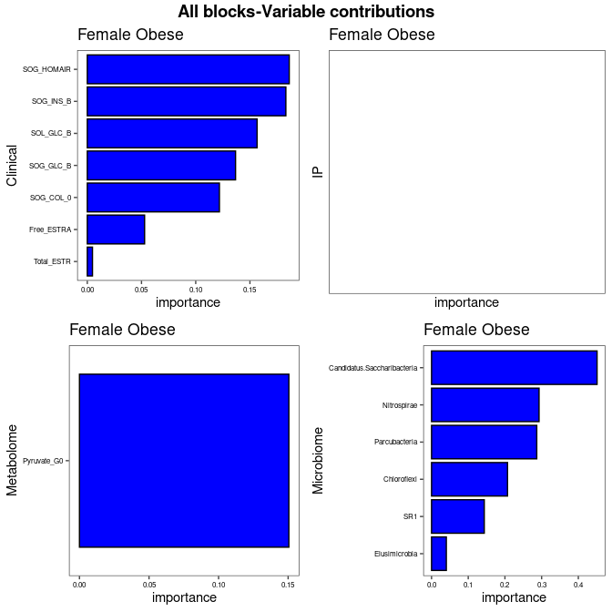

```r
> aux2 <- vector(mode = "list", length = 4)
> for (i in 1:length(lista_loads)) {
+
+     aux2[[i]] <- fn.contrib(lista_loads[[i]], grupcon1 = grupos.con[2, 1], grupcon2 = grupos.con[2,
+         2]) + labs(x = block.name[i])
+ }
>
> plot_female_obese <- ggarrange(aux2[[1]], aux2[[2]], aux2[[3]], aux2[[4]])
> annotate_figure(plot_female_obese, top = text_grob("All blocks-Variable contributions",
+     color = "black", face = "bold", size = 14))
```

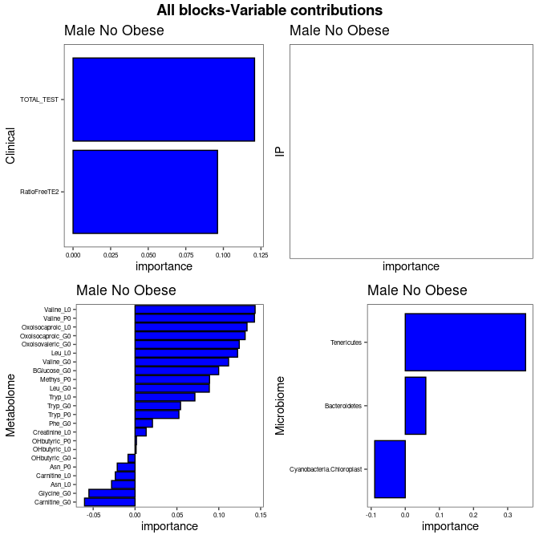

```r
> aux3 <- vector(mode = "list", length = 4)
> for (i in 1:length(lista_loads)) {
+
+     aux3[[i]] <- fn.contrib(lista_loads[[i]], grupcon1 = grupos.con[3, 1], grupcon2 = grupos.con[3,
+         2]) + labs(x = block.name[i])
+ }
>
> plot_male <- ggarrange(aux3[[1]], aux3[[2]], aux3[[3]], aux3[[4]])
> annotate_figure(plot_male, top = text_grob("All blocks-Variable contributions", color = "black",
+     face = "bold", size = 14))
```

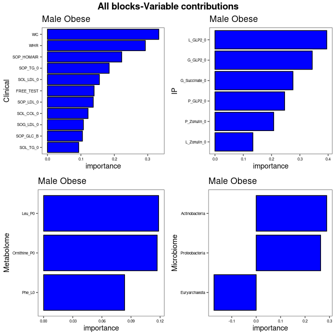

```r
> aux4 <- vector(mode = "list", length = 4)
> for (i in 1:length(lista_loads)) {
+
+     aux4[[i]] <- fn.contrib(lista_loads[[i]], grupcon1 = grupos.con[4, 1], grupcon2 = grupos.con[4,
+         2]) + labs(x = block.name[i])
+ }
>
> plot_male_obese <- ggarrange(aux4[[1]], aux4[[2]], aux4[[3]], aux4[[4]])
> annotate_figure(plot_male_obese, top = text_grob("All blocks-Variable contributions",
+     color = "black", face = "bold", size = 14))
```

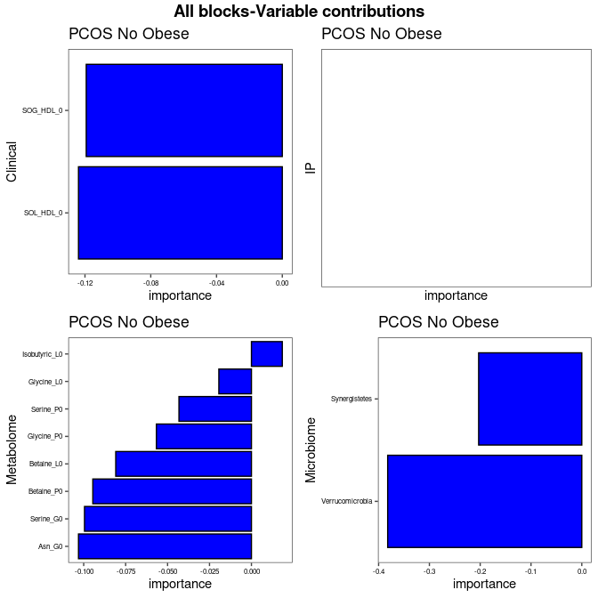

```r
> aux5 <- vector(mode = "list", length = 4)
> for (i in 1:length(lista_loads)) {
+
+     aux5[[i]] <- fn.contrib(lista_loads[[i]], grupcon1 = grupos.con[5, 1], grupcon2 = grupos.con[5,
+         2]) + labs(x = block.name[i])
+ }
>
> plot_pcos <- ggarrange(aux5[[1]], aux5[[2]], aux5[[3]], aux5[[4]])
> annotate_figure(plot_pcos, top = text_grob("All blocks-Variable contributions", color = "black",
+     face = "bold", size = 14))
```

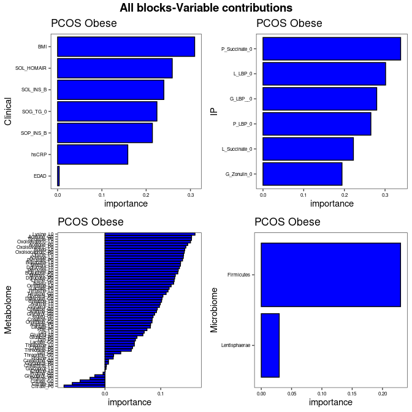

```r
> aux6 <- vector(mode = "list", length = 4)
> for (i in 1:length(lista_loads)) {
+
+     aux6[[i]] <- fn.contrib(lista_loads[[i]], grupcon1 = grupos.con[6, 1], grupcon2 = grupos.con[6,
+         2]) + labs(x = block.name[i])
+ }
>
> plot_pcos_obese <- ggarrange(aux6[[1]], aux6[[2]], aux6[[3]], aux6[[4]])
> annotate_figure(plot_pcos_obese, top = text_grob("All blocks-Variable contributions",
+     color = "black", face = "bold", size = 14))
```

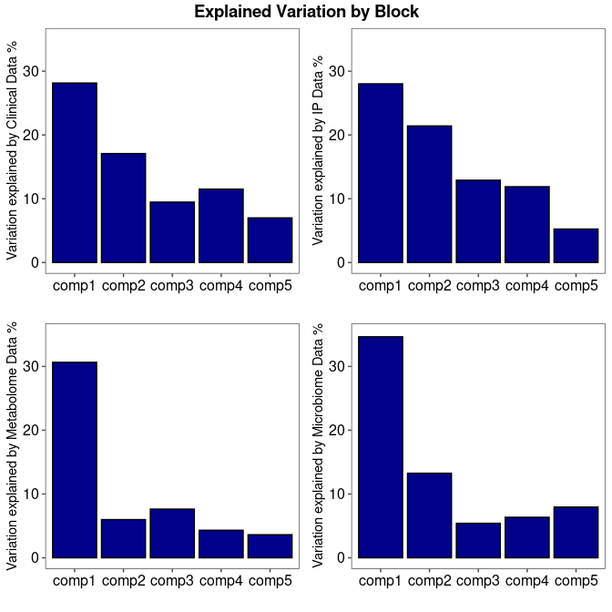

```r
> c_prop <- sgccda.res_genus$prop_expl_var$clinical_data
> ip_prop <- sgccda.res_genus$prop_expl_var$IP
> met_prop <- sgccda.res_genus$prop_expl_var$metabolome
> mic_prop <- sgccda.res_genus$prop_expl_var$microbiome
> Y_prop <- sgccda.res_genus$prop_expl_var$Y
> var.exp <- 100 * data.frame(clinical = c_prop, ip = ip_prop, met = met_prop, mic = mic_prop,
+     Y = Y_prop)
> var.exp$comps <- rownames(var.exp)
> p1 <- ggplot(data = var.exp, aes(x = comps, y = clinical)) + geom_bar(stat = "identity",
+     col = "black", fill = "darkblue") + theme_article() + labs(y = "Variation explained by Clinical Data %",
+     x = "") + theme(axis.text = element_text(size = 12, color = "black")) + coord_cartesian(ylim = c(-0,
+     35))
>
> p2 <- ggplot(data = var.exp, aes(x = comps, y = ip)) + geom_bar(stat = "identity",
+     col = "black", fill = "darkblue") + theme_article() + labs(y = "Variation explained by IP Data %",
+     x = "") + theme(axis.text = element_text(size = 12, color = "black")) + coord_cartesian(ylim = c(-0,
+     35))
>
> p3 <- ggplot(data = var.exp, aes(x = comps, y = met)) + geom_bar(stat = "identity",
+     col = "black", fill = "darkblue") + theme_article() + labs(y = "Variation explained by Metabolome Data %",
+     x = "") + theme(axis.text = element_text(size = 12, color = "black")) + coord_cartesian(ylim = c(-0,
+     35))
>
> p4 <- ggplot(data = var.exp, aes(x = comps, y = mic)) + geom_bar(stat = "identity",
+     col = "black", fill = "darkblue") + theme_article() + labs(y = "Variation explained by Microbiome Data %",
+     x = "") + theme(axis.text = element_text(size = 12, color = "black")) + coord_cartesian(ylim = c(-0,
+     35))
>
> p5 <- ggplot(data = var.exp, aes(x = comps, y = Y)) + geom_bar(stat = "identity",
+     col = "black", fill = "darkblue") + theme_article() + labs(y = "Variation explained by thre response %",
+     x = "") + theme(axis.text = element_text(size = 12, color = "black")) + coord_cartesian(ylim = c(-0,
+     35))
>
> var.expl.plot <- ggarrange(p1, p2, p3, p4)
> annotate_figure(var.expl.plot, top = text_grob("Explained Variation by Block", color = "black",
+     face = "bold", size = 14))
```

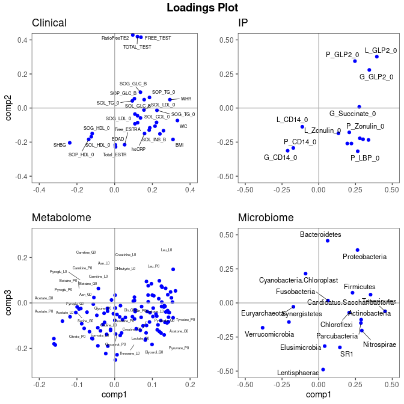

```r
> X <- data.frame(sgccda.res_genus$loadings$clinical_data)
> Y <- data.frame(sgccda.res_genus$loadings$IP)
> Z <- data.frame(sgccda.res_genus$loadings$metabolome)
> W <- data.frame(sgccda.res_genus$loadings$microbiome)
> # colnames(X) <-paste0('met',colnames(X)) colnames(Y) <-
> # paste0('micro',colnames(Y))
> plot1 <- ggplot() + geom_point(data = X, aes(comp1, comp2), label = rownames(X),
+     color = "blue") + geom_text_repel(data = X, aes(comp1, comp2, label = rownames(X)),
+     segment.size = 0.25, size = 2) + coord_cartesian(xlim = c(-0.4, 0.4), ylim = c(-0.4,
+     0.4)) + theme_article() + geom_hline(yintercept = 0, color = "gray70") + geom_vline(xintercept = 0,
+     color = "gray70") + labs(x = "") + ggtitle("Clinical")
>
>
> plot2 <- ggplot() + geom_point(data = Y, aes(comp1, comp2), color = "blue") + geom_text_repel(data = Y,
+     aes(comp1, comp2, label = rownames(Y)), segment.size = 0.25, size = 3) + coord_cartesian(xlim = c(-0.5,
+     0.5), ylim = c(-0.5, 0.5)) + theme_article() + geom_hline(yintercept = 0, color = "gray70") +
+     geom_vline(xintercept = 0, color = "gray70") + labs(x = "", y = "") + ggtitle("IP")
> plot3 <- ggplot() + geom_point(data = Z, aes(comp1, comp3), color = "blue") + geom_text_repel(data = Z,
+     aes(comp1, comp2, label = rownames(Z)), segment.size = 0.2, size = 1.5) + coord_cartesian(xlim = c(-0.2,
+     0.2), ylim = c(-0.3, 0.3)) + theme_article() + geom_hline(yintercept = 0, color = "gray70") +
+     geom_vline(xintercept = 0, color = "gray70") + ggtitle("Metabolome")
> plot4 <- ggplot() + geom_point(data = W, aes(comp1, comp2), color = "blue") + geom_text_repel(data = W,
+     aes(comp1, comp2, label = rownames(W)), segment.size = 0.25, size = 3) + coord_cartesian(xlim = c(-0.5,
+     0.5), ylim = c(-0.5, 0.5)) + theme_article() + geom_hline(yintercept = 0, color = "gray70") +
+     geom_vline(xintercept = 0, color = "gray70") + labs(y = "") + ggtitle("Microbiome")
> loadsplot <- ggarrange(plot1, plot2, plot3, plot4)
>
> annotate_figure(loadsplot, top = text_grob("Loadings Plot", color = "black", face = "bold",
+     size = 14))
```

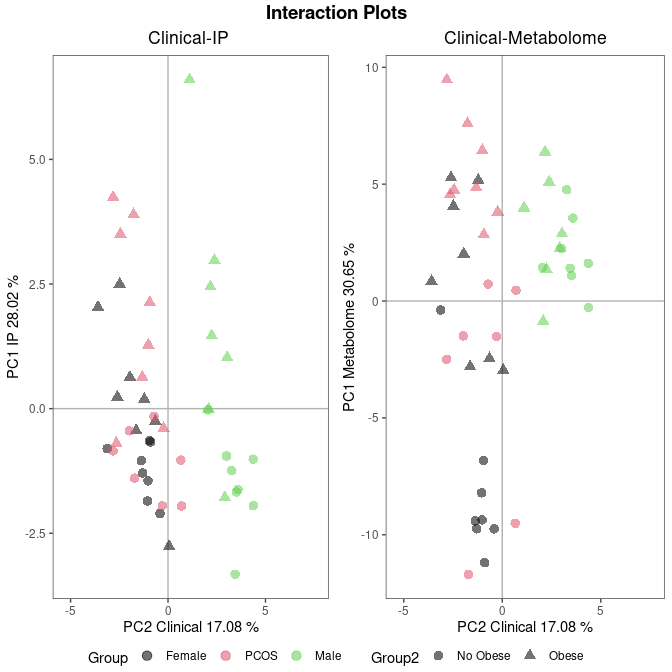

```r
> X <- data.frame(sgccda.res_genus$variates$clinical_data)
> colnames(X) <- paste0("C_", colnames(X))
> Y <- data.frame(sgccda.res_genus$variates$IP)
> colnames(Y) <- paste0("IP_", colnames(Y))
> Z <- data.frame(sgccda.res_genus$variates$metabolome)
> colnames(Z) <- paste0("Met_", colnames(Z))
> W <- data.frame(sgccda.res_genus$variates$microbiome)
> colnames(W) <- paste0("Micro_", colnames(W))
>
> datos_comb1 <- data.frame(c(X, Y))
>
> p5 <- ggplot(datos_comb1, aes(C_comp2, IP_comp1)) + theme_article() + geom_hline(yintercept = 0,
+     color = "gray70") + geom_vline(xintercept = 0, color = "gray70") + geom_point(aes(color = Group,
+     shape = Group2), alpha = 0.55, size = 3) + coord_cartesian(xlim = c(min(datos_comb1[,
+     1]), max(datos_comb1[, 1]))) + scale_fill_discrete(name = "Group") + labs(x = c(paste("PC2 Clinical",
+     round(100 * sgccda.res_genus$prop_expl_var$clinical_data[2], 2), "%")), y = c(paste("PC1 IP",
+     round(100 * sgccda.res_genus$prop_expl_var$IP[1], 2), "%"))) + ggtitle(paste("Clinical-IP ",
+     sep = " ")) + theme(plot.title = element_text(hjust = 0.5), legend.position = "none") +
+     scale_color_manual(values = 1:3)
>
> datos_comb1 <- data.frame(c(X, Z))
>
> p6 <- ggplot(datos_comb1, aes(C_comp2, Met_comp1)) + theme_article() + geom_hline(yintercept = 0,
+     color = "gray70") + geom_vline(xintercept = 0, color = "gray70") + geom_point(aes(color = Group,
+     shape = Group2), alpha = 0.55, size = 3) + coord_cartesian(xlim = c(min(datos_comb1[,
+     1]), max(datos_comb1[, 1]))) + scale_fill_discrete(name = "Group") + labs(x = c(paste("PC2 Clinical",
+     round(100 * sgccda.res_genus$prop_expl_var$clinical_data[2], 2), "%")), y = c(paste("PC1 Metabolome",
+     round(100 * sgccda.res_genus$prop_expl_var$metabolome[1], 2), "%"))) + ggtitle(paste("Clinical-Metabolome",
+     sep = " ")) + theme(plot.title = element_text(hjust = 0.5), legend.position = "none") +
+     scale_color_manual(values = 1:3)
>
>
> p <- ggarrange(p5, p6, common.legend = T, nrow = 1, ncol = 2, legend = "bottom")
> annotate_figure(p, top = text_grob("Interaction Plots", color = "black", face = "bold",
+     size = 14))
```